# POP77022: Programming Exercise 1

Ciara O’Flaherty

14-02-2023

## Overview

The first homework assignment will cover concepts and methods from Weeks 1 & 2 (basic string operations, corpus acquisition, text processing, textual statistics, dictionary methods). You are expected to provide your answers as embedded R code and/or text answers in the chunks provided in the homework RMarkdown file.

For example:

```r
print("Print R code in code chunk.")
```

```
## [1] "Print R code in code chunk."
```

```
Describe results and provide answers to conceptual and open-ended questions
in a plain code block like this one.
```

**The programming exercise is worth 20% of your total grade. The questions sum to 100 points.**

## Analysis of tweets during a political crisis

We will start with a dataset that contains almost 900 tweets that were published by four central figures in American politics around the time of the onset of an impeachment inquiry: Pres. Donald Trump, Rudy Giuliani, Speaker of the House Rep. Nancy Pelosi, and Chair of the House Intelligence Committee Rep. Adam Schiff.

The first step will be to read the spreadsheet of tweets into R and then use the `str` and `head` functions to describe the variables and contents of the dataset. For your convenience, I will provide code to import the spreadsheet (*Hint: be sure that the data folder is in the same folder as this homework RMarkdown file.*)

```r
setwd(getwd())
data <- read.csv("./data/us_tweets.csv",
                 stringsAsFactors=FALSE,
                 encoding = "utf-8")
```

### Question 1.0 (2 points)

Print the number of tweets that are in this dataset.

```r
# Insert code here
require(dplyr)

tweet_number <- nrow(data)
tweet_number
```

```
## [1] 899
```

### Question 1.1 (3 points)

Create a new dataframe that only includes original tweets (remove retweets) and print the number of rows.

```r
# Insert code here
df <- as_tibble(data)

df <- df %>%
  filter(is_retweet == "FALSE")
nrow(df)
```

```
## [1] 662
```

### Question 1.2 (20 points)

Create a smaller dataframe that only includes tweets by Donald Trump.

- Print how many tweets by Trump are contained in the dataset?

For the following print the number of instances as well as an example tweet:

- How many tweets include an exclamation mark?
- In how many tweets did Trump mention words related to “winning”?
- “employment”?
- “immigration”?
- “hoax”?

Make sure that you support your answers with code.

(*Hints: be sure to use regular expressions when searching the tweets; also you might want to wrap your search term in between word anchor boundaries (`\\b`). For instance, for the term health: `"\\bhealth\\b"`*)

```r
## df for dt tweets
df_dt <- df %>%
  filter(screen_name == "realDonaldTrump")
nrow(df_dt)
```

```
## [1] 377
```

```r
## dt tweets with exclamation points
df_dt_exc <- df_dt %>%
  filter(grepl("!", text, ignore.case = TRUE))
print(list(nrow(df_dt_exc), df_dt_exc$text[246]))
```

```
## [[1]]
## [1] 261
##
## [[2]]
## [1] "Illegal Immigration costs the USA over 300 Billion Dollars a year. There is no reason for this, and things are being set in motion to have this number come WAY DOWN. Democrats could end Loopholes and it would be a whole lot easier, and faster. But it will all happen anyway!...."
```

```r
## winning
# tidying tibble
tidydt <- df_dt %>%
  select(X,
         text,
         created_at
  )

tidydt_win <- tidydt %>%
  filter(
    grepl(pattern = '\\bwon\\b|\\bwin\\b|\\bwins\\b|winn', text, ignore.case = TRUE)
    )
print(list(nrow(tidydt_win), tidydt_win$text[5]))
```

```
## [[1]]
## [1] 25
##
## [[2]]
## [1] "You cannot judge my Stock Market performance since the Inauguration, which was very good, but only from the day after the big Election Win, which was spectacular due to the euphoria of getting Obama/Biden OUT, &amp; getting Trump/Pence IN. WentI up BIG between Nov. 9 &amp; Inauguration!"
```

```r
## employment
tidydt_emp <- tidydt %>%
  filter(grepl('\\bjobs\\b|employ', text, ignore.case = TRUE)) # 'job' alone personal
print(list(nrow(tidydt_emp), tidydt_emp$text[1]))
```

```
## [[1]]
## [1] 6
##
## [[2]]
## [1] "Breaking News: Unemployment Rate, at 3.5%, drops to a 50 YEAR LOW. Wow America, lets impeach your President (even though he did nothing wrong!)."
```

```r
## immigration
tidydt_imm <- tidydt %>%
  filter(grepl('immigr', text, ignore.case = TRUE))
print(list(nrow(tidydt_imm), tidydt_imm$text[3]))
```

```
## [[1]]
## [1] 4
##
## [[2]]
## [1] "....VERY stupidly negotiated Trade Deals, and Illegal Immigration, are a tremendous cost and burden to our Country. They are BOTH coming along very well and someday, in the not too distant future, America will see a very positive change. Remember, America First!"
```

```r
## hoax
tidydt_hoax <- tidydt %>%
  filter(grepl(pattern = 'hoax', text, ignore.case = TRUE))
print(list(nrow(tidydt_hoax), tidydt_hoax$text[2]))
```

```
## [[1]]
## [1] 5
##
## [[2]]
## [1] "“The congratulatory phone call with the Ukrainian President was PERFECT, unless you heard Liddle’ Adam Schiff’s fraudulently made up version of the call. This is just another Fake News Media, together with their partner, the Democrat Party, HOAX!"
```

### Question 2 (75 points)

Create a `corpus` and a `dfm` object with processed text (including collocations) using the dataframe generated in Question 1.1. With the generated `dfm` object perform the following tasks:

1. Create a frequency plot of the top 30 tokens for each politician.
2. Determine the “key” terms that Trump and Pelosi are more likely to tweet. Plot your results
3. Perform a keyword in context analysis using your `corpus` object for some of the most distinct keywords from both Trump and Pelosi. *Hint: remember to use the `phrase` function in the `pattern` argument of `kwic`*
4. Conduct a sentiment analysis of Trump’s tweets using the Lexicon Sentiment Dictionary. Plot net sentiment over the entire sample period. Interpret the results. *Hint: you might want to use `lubridate` to generate a date object variable from the “created_at” variable before plotting. For example: `docvars(dfm, "date") <- lubridate::ymd_hms(dfm@docvars$created_at)`*
5. Justify each of your text processing decisions and interpret your results in the text field below. What can we learn about the political communication surrounding the political crisis based on the results from the above tasks?

```r
require(dplyr)
require(textstem)
require(quanteda)
require(quanteda.textstats)
require(lubridate)
require(ggplot2)

## Make a corpus object
tidy_df <- df %>%
  select(X,
         screen_name,
         text,
         datetime = created_at
  ) %>%
  mutate(datetime = as_datetime(datetime))

corpus_df <- corpus(tidy_df,
                     docid_field = "X",
                     text_field = "text")

### creating dfm

## Make tokens
tokns <- quanteda::tokens(corpus_df,
                         remove_punct = TRUE,
                         remove_symbols = TRUE)
tokns <- tokens_tolower(tokns)
stop_list <- stopwords("english")
tokns <- tokens_remove(tokns, c(stop_list, "amp"))

## stemming
stem_tokns <- tokens_wordstem(tokns)

# identify collocations
collocations <- textstat_collocations(stem_tokns, size = 2) # interesting to #30
coll_list <- collocations$collocation[1:30]

# combine with tokens list
complete_tokns <- tokens_compound(stem_tokns, coll_list)

# convert to a dfm
dfm_twt <- dfm(complete_tokns)
```

```r
## top 30 terms by politician

unique(tidy_df$screen_name) # 4 # "RudyGiuliani"    "SpeakerPelosi"   "RepAdamSchiff"   "realDonaldTrump"
```

```
## [1] "RudyGiuliani"    "SpeakerPelosi"   "RepAdamSchiff"   "realDonaldTrump"
```

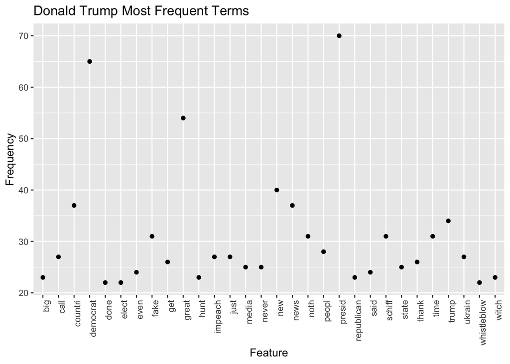

```r
freq_feat_dt <- dfm_twt %>%
  dfm_subset(screen_name == "realDonaldTrump") %>%
  textstat_frequency(., n = 30) %>%
  ggplot(aes(x = feature, y = frequency)) +
  geom_point() +
  theme(axis.text.x = element_text(angle = 90, hjust = 1))+
  xlab("Feature")+
  ylab("Frequency")+
  ggtitle("Donald Trump Most Frequent Terms")
freq_feat_dt
```

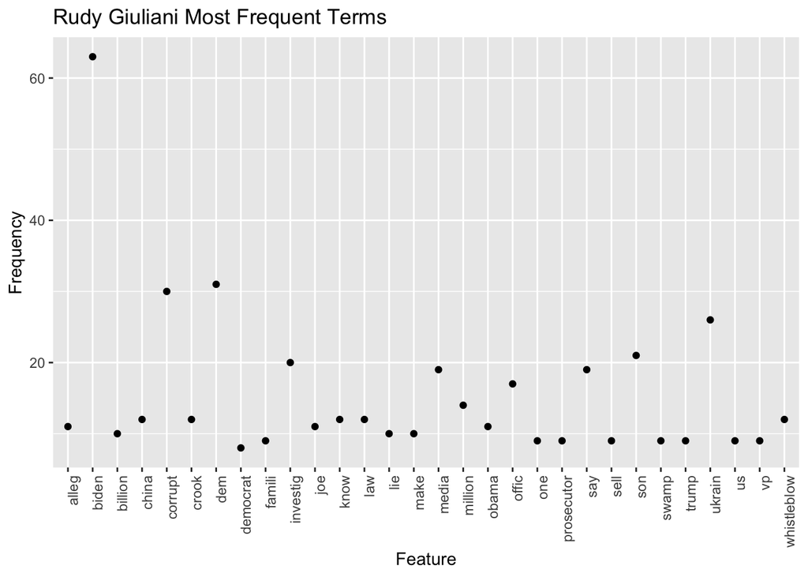

```r
freq_feat_rg <- dfm_twt %>%
  dfm_subset(screen_name == "RudyGiuliani") %>%
  textstat_frequency(., n = 30) %>%
  ggplot(aes(x = feature, y = frequency)) +
  geom_point() +
  theme(axis.text.x = element_text(angle = 90, hjust = 1))+
  xlab("Feature")+
  ylab("Frequency")+
  ggtitle("Rudy Giuliani Most Frequent Terms")
freq_feat_rg
```

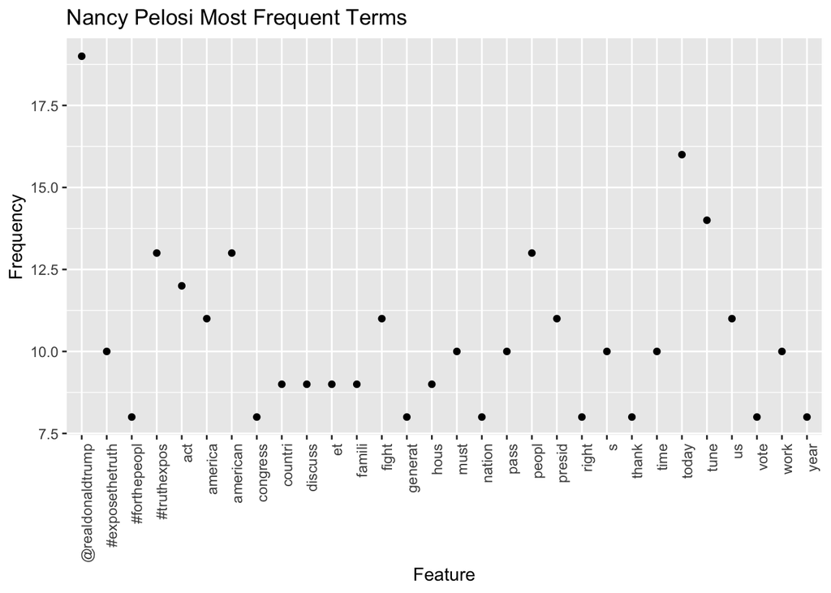

```r
freq_feat_np <- dfm_twt %>%
  dfm_subset(screen_name == "SpeakerPelosi") %>%
  textstat_frequency(., n = 30) %>%
  ggplot(aes(x = feature, y = frequency)) +
  geom_point() +
  theme(axis.text.x = element_text(angle = 90, hjust = 1))+
  xlab("Feature")+
  ylab("Frequency")+
  ggtitle("Nancy Pelosi Most Frequent Terms")
freq_feat_np
```

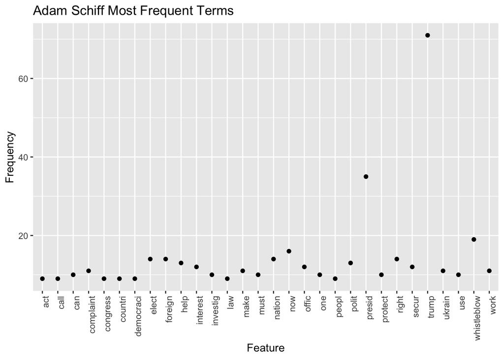

```r
freq_feat_as <- dfm_twt %>%
  dfm_subset(screen_name == "RepAdamSchiff") %>%
  textstat_frequency(., n = 30) %>%
  ggplot(aes(x = feature, y = frequency)) +
  geom_point() +
  theme(axis.text.x = element_text(angle = 90, hjust = 1))+
  xlab("Feature")+
  ylab("Frequency")+
  ggtitle("Adam Schiff Most Frequent Terms")
freq_feat_as
```

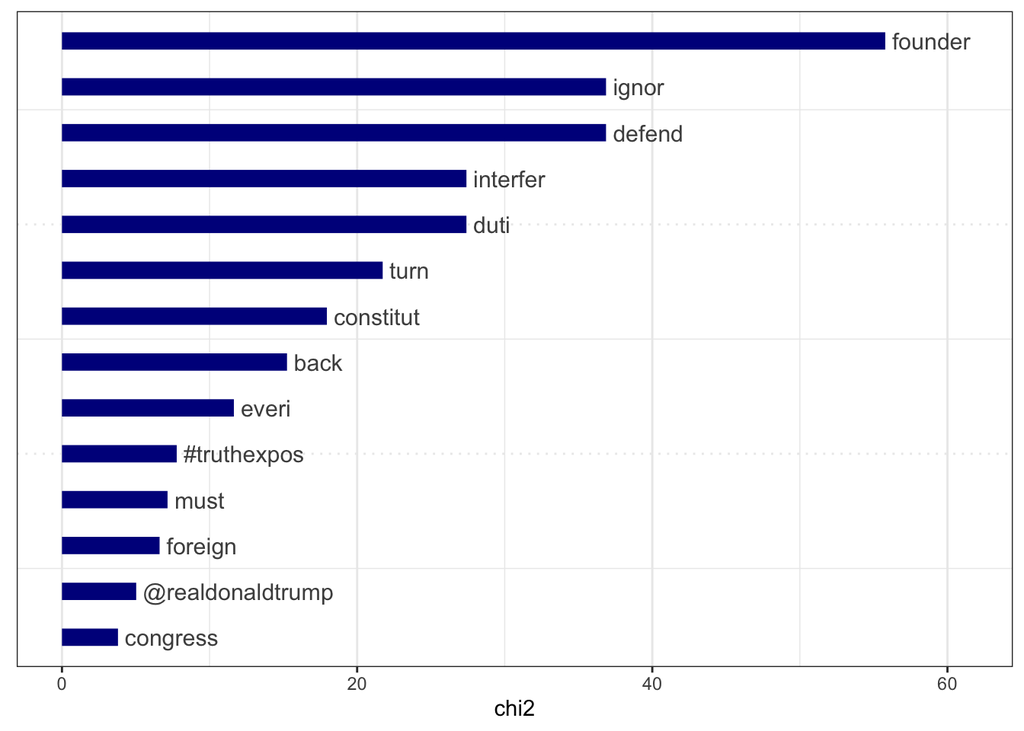

```r
dfm_np_dt <- dfm_twt %>%
  dfm_subset(screen_name == "realDonaldTrump" | screen_name =="SpeakerPelosi") # %>%

result_keyness <- textstat_keyness(dfm_np_dt)
textplot_keyness(result_keyness, show_reference = FALSE)
```

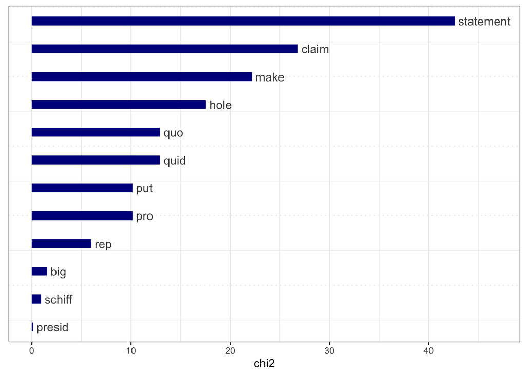

```r
# donald trump alone
dfm_key_dt <- dfm_twt %>%
  dfm_subset(screen_name == "realDonaldTrump")

result_keyness_dt <- textstat_keyness(dfm_key_dt)
textplot_keyness(result_keyness_dt, show_reference = FALSE)
```

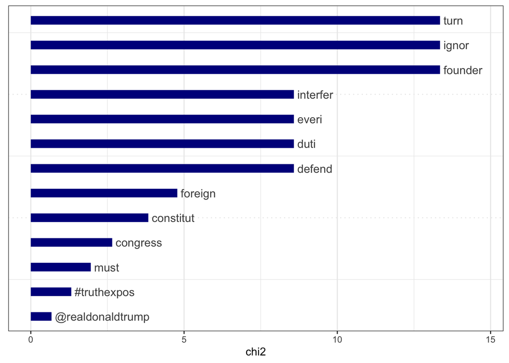

```r
# nancy pelosi alone
dfm_key_np <- dfm_twt %>%
  dfm_subset(screen_name == "SpeakerPelosi")

result_keyness_np <- textstat_keyness(dfm_key_np)
textplot_keyness(result_keyness_np, show_reference = FALSE)
```

```r
## Sentiment analysis

dfm_sentiment <- dfm_lookup(dfm_key_dt, data_dictionary_LSD2015[1:2]) %>%
dfm_group(groups = datetime)
dfm_sentiment
```

```
## Document-feature matrix of: 359 documents, 2 features (47.49% sparse) and 2 docvars.
##                      features
## docs                  negative positive
##   2019-09-11 12:21:36        0        2
##   2019-09-11 17:23:45        1        6
##   2019-09-11 22:47:46        0        1
##   2019-09-11 23:17:18        1        0
##   2019-09-11 23:17:19        0        3
##   2019-09-12 00:23:15        1        3
## [ reached max_ndoc ... 353 more documents ]
```

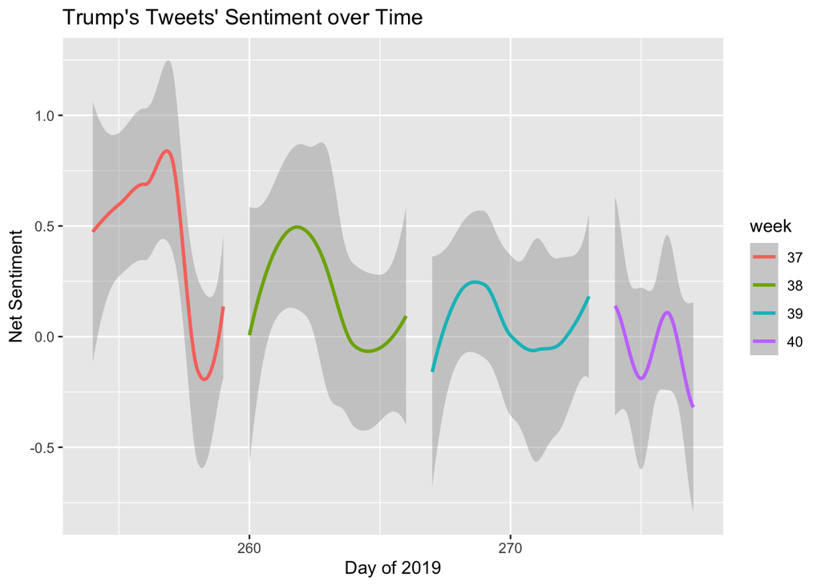

[output not shown]

```r
docvars(dfm_sentiment, "prop_negative") <- as.numeric(dfm_sentiment[,1] / ntoken(dfm_sentiment))
docvars(dfm_sentiment, "prop_positive") <- as.numeric(dfm_sentiment[,2] / ntoken(dfm_sentiment))
docvars(dfm_sentiment, "net_sentiment") <- docvars(dfm_sentiment, "prop_positive") - docvars(dfm_sentiment,"prop_negative")

docvars(dfm_sentiment) %>%
  ggplot(aes(x = yday(datetime), y = net_sentiment, group = week(datetime))) + #yday is suitable
  geom_smooth(aes(colour = as.character(week(datetime)))) +
  labs(title = "Trump's Tweets' Sentiment over Time",
       x = "Day of 2019", y = "Net Sentiment",
       colour = "week")
```